# Mapping Lebanon

Daniel K Baissa

2/13/2022

## Intro

My goal in the document is to merge the data from the Voter Database of Lebanon scrapped by David and merge it to a shapefile. We tried matching via admin3 in Arabic and for whatever reason, there was a lot of missing data. Therefore my strategy is to brute force it by searching for each location via the Google api and the googleway library.

I will start by loading the the libraries

Now let’s load in the data

```r
Lebanon_shp <- st_read("Data/Lebanon Shapes/lbn_admbnda_adm3_cdr_20200810.shp")
votreg_full <- readRDS("Data/Voter_Data/votreg_full.RDS")
Lat_Long_votreg_best_matches <- read_csv("Data/Googled_Data/Lat_Long_votreg_best_matches_full.csv")
Lat_Long_votreg_next_best_matches <- read_csv("Data/Googled_Data/Lat_Long_votreg_next_best_matches_full.csv")
```

## Aggregating the Data

Now that we know what the data look like we can start aggregating by admin 3 level. I will also add some population percentage variables while doing this.

```r
df <- votreg_full %>%
  group_by(sect_en, adm_03_ar) %>%
  summarise(Population_Local = n()) %>%
  ungroup() %>%
  group_by(adm_03_ar) %>%
  mutate(Percentage_Local = (Population_Local/sum(Population_Local))*100) %>%
  ungroup() %>%
  pivot_wider(names_from = sect_en, values_from = c(Percentage_Local, Population_Local))
df
```

```
## # A tibble: 1,550 x 65
##    adm_03_ar Percentage_Loca~ `Percentage_Loc~ `Percentage_Loc~ `Percentage_Loc~
##    <chr>                <dbl>            <dbl>            <dbl>            <dbl>
##  1 ارده                0.0897           NA               0.179            NA
##  2 ارنون               0.103            NA              NA                NA
##  3 اصنون               0.192            NA              NA                NA
##  4 الاشرفية            0.0531            4.04           13.3               0.390
##  5 البابلية            0.0285           NA               0.0285           NA
##  6 الباشورة            0.0339            0.531           1.92              0.162
##  7 البترون             0.0782            0.704           2.05             NA
##  8 البداوي             0.365            NA               0.0140           NA
##  9 البرج               0.0672           NA              NA                NA
## 10 البستان             0.0468           NA              NA                NA
## # ... with 1,540 more rows, and 60 more variables:
## #   Percentage_Local_Assyrian <dbl>, Percentage_Local_Bahai <dbl>,
## #   Percentage_Local_Buddhist <dbl>, Percentage_Local_Chaldean <dbl>,
## #   Percentage_Local_Chaldean Catholic <dbl>,
## #   Percentage_Local_Chaldean Orthodox <dbl>, Percentage_Local_Christian <dbl>,
## #   Percentage_Local_Coptic <dbl>, Percentage_Local_Coptic Catholic <dbl>,
## #   Percentage_Local_Coptic Orthodox <dbl>, ...
```

Next I will create a dataset of distinct admin 2 and 3 names.

```r
loc <- votreg_full %>%
  select(adm_02_ar, adm_03_ar) %>%
  distinct(adm_03_ar, .keep_all = TRUE)
```

```r
# df <- votreg_full %>%
#   group_by(sect_en, adm_03_ar) %>%
#   summarise(Population_Local = n()) %>%
#   ungroup() %>%
#   group_by(adm_03_ar) %>%
#   mutate(Percentage_Local = (Population_Local/sum(Population_Local))*100) %>%
#   ungroup() %>%
#   left_join(vote_percentage,
#               by = "sect_en") %>%
#   rename(Population_National = Count) %>%
#   rename(Percentage_National = Percentage)
```

### Matches with admin 2 and admin3

When using the Googleway library I searched with the criteria of admin3, admin2, and Lebanon. Therefore, these should be the best matches. This resulted in 1200 matches. The matches make up 77.4193548% of all cases.

Now let’s make sure that there are no strange coordinates. When working with the RA Jana, we found some places may not be in Lebanon. So I will double check everything at every step.

```r
mapview(na.omit(Lat_Long_votreg_best_matches), xcol = "lon", ycol = "lat", crs = 4269, grid = FALSE)
```

[interactive chart not shown]

These seem to have worked. Now I will see how these coordinates map onto the shapefile.

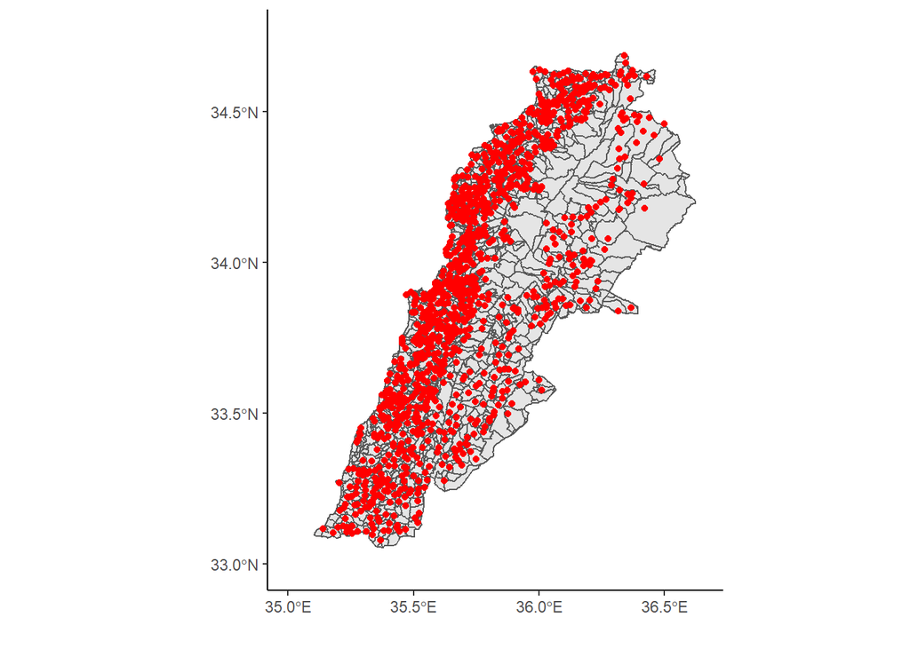

```r
ggplot(data = Lebanon_shp) +
  geom_sf() +
  geom_point(data = Lat_Long_votreg_best_matches, aes(y = lat, x = lon), color = 'red') +
    coord_sf(xlim = c(35, 36.65), ylim = c(33, 34.75), expand = TRUE)+
  theme_classic()+
  xlab("")+ylab("")
```

It almost looks like there might be several points per admin 3 zone. So I will zoom in the map in a few places to check.

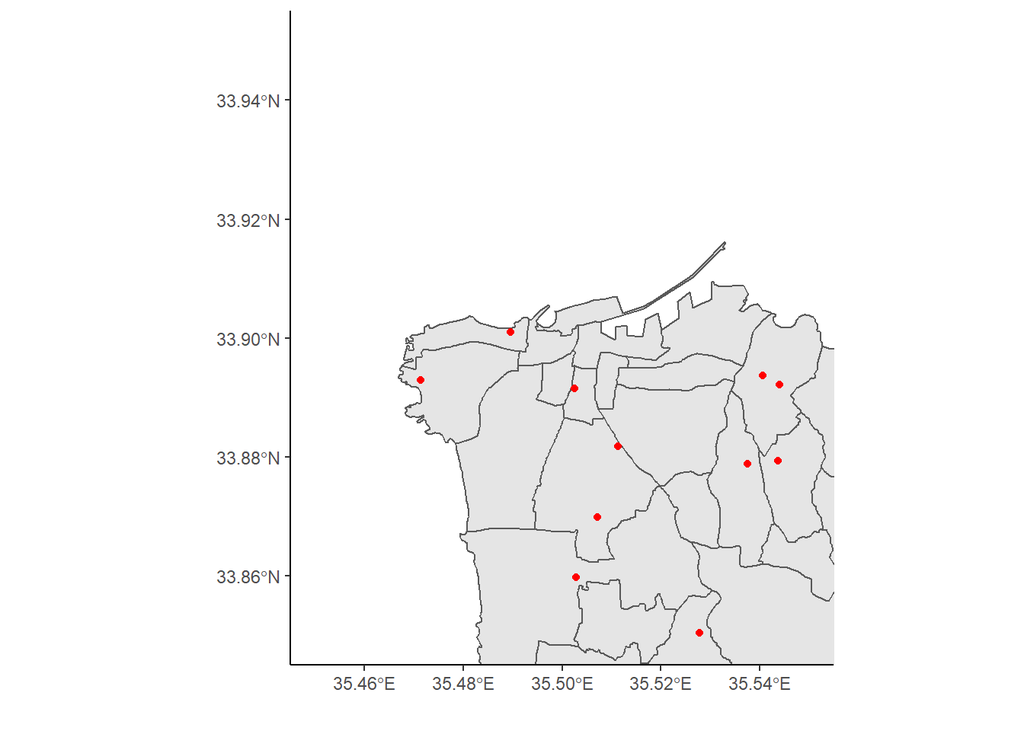

```r
ggplot(data = Lebanon_shp) +
  geom_sf() +
  geom_point(data = Lat_Long_votreg_best_matches, aes(y = lat, x = lon), color = 'red') +
   coord_sf(xlim = c(35.45, 35.55), ylim = c(33.85, 33.95), expand = TRUE)+
  theme_classic()+
  xlab("")+ylab("")
```

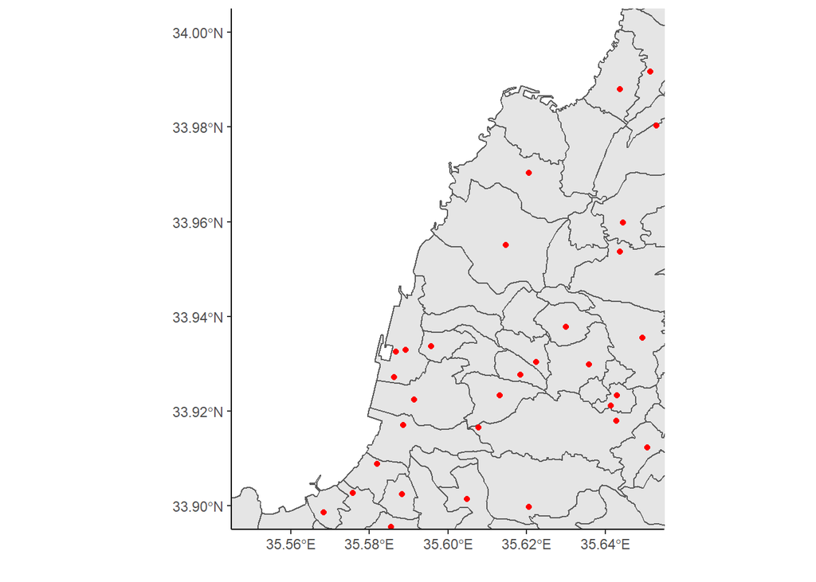

```r
ggplot(data = Lebanon_shp) +
  geom_sf() +
  geom_point(data = Lat_Long_votreg_best_matches, aes(y = lat, x = lon), color = 'red') +
   coord_sf(xlim = c(35.55, 35.65), ylim = c(33.9, 34), expand = TRUE)+
  theme_classic()+
  xlab("")+ylab("")
```

For the most part the coordinates map on well. However, there are some cases where there are multiple points in a single admin 3 shape. Maybe this is because the district boundries changed?

### Matches without admin 2

After searching for the locations with both the admin 2 and admin 3 critera, I searched the remaining misses with just the admin 3 name and Lebanon. This resulted in an additional 111 matches. Combinded with the best matches it accounts for 84.5806452% of all cases.

```r
mapview(na.omit(Lat_Long_votreg_next_best_matches), xcol = "lon", ycol = "lat", crs = 4269, grid = FALSE)
```

[interactive chart not shown]

Now we see there are places outside of Lebanon showing up in the data.

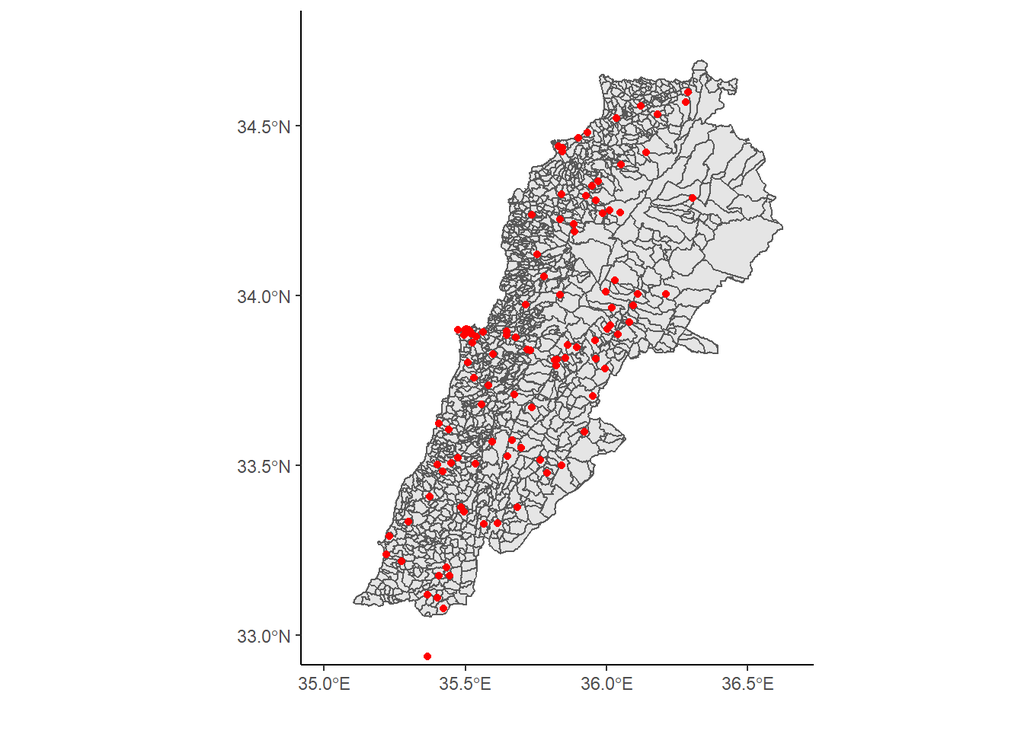

```r
ggplot(data = Lebanon_shp) +
  geom_sf() +
  geom_point(data = Lat_Long_votreg_next_best_matches, aes(y = lat, x = lon), color = 'red') +
  coord_sf(xlim = c(35, 36.65), ylim = c(33, 34.75), expand = TRUE)+
  theme_classic()+
  xlab("")+ylab("")
```